# MSstats PSM-Level Proteomics Analysis

```r
  volcano_plot <- EnhancedVolcano::EnhancedVolcano(
    plot_data,
    lab = plot_data$.volcano_label,
    x = fc_col,
    y = ".volcano_p",
    selectLab = top_labels,
    pCutoff = params$volcano_p_cutoff,
    FCcutoff = params$volcano_fc_cutoff,
    title = gsub(
      "_", " ",
      sub("_vs_", "/", comparison_label, fixed = TRUE),
      fixed = TRUE
    ),
    subtitle = "MSstats protein-level comparison",
    caption = paste0(
      "Adjusted p < ", params$volcano_p_cutoff,
      "; |log2FC| > ", params$volcano_fc_cutoff
    ),
    xlab = "Log2 fold change",
    ylab = "-Log10 adjusted p-value",
    pointSize = 2.2,
    labSize = 4.0,
    col = c("grey78", "grey45", "#4C72B0", "#C44E52"),
    colAlpha = 0.82,
    legendLabels = c(
      "Not significant",
      "Meets absolute log2 fold-change threshold only",
      "Meets adjusted p-value threshold only",
      "Meets both adjusted p-value and fold-change thresholds"
    ),
    legendPosition = "bottom",
    legendLabSize = 9,
    legendIconSize = 3.5,
    drawConnectors = TRUE,
    widthConnectors = 0.35,
    colConnectors = "grey35"
  ) +
    theme_classic(base_size = 12) +
    theme(
      plot.title = element_text(face = "bold", size = 16, margin = margin(b = 5)),
      plot.subtitle = element_text(size = 11, color = "grey30", margin = margin(b = 8)),
      plot.caption = element_text(size = 9, color = "grey30", margin = margin(t = 8)),
      axis.title = element_text(face = "bold", size = 12),
      axis.text = element_text(size = 10, color = "black"),
      legend.title = element_blank(),
      legend.position = "bottom",
      legend.box = "vertical",
      legend.text = element_text(size = 9),
      legend.margin = margin(t = 8),
      plot.margin = margin(12, 18, 12, 12)
    ) +
    guides(
      colour = guide_legend(nrow = 2, byrow = TRUE),
      shape = guide_legend(nrow = 2, byrow = TRUE)
    )

  static_plot <- apply_split_axes(volcano_plot, plot_data, fc_col, ".volcano_p")
  static_file <- file.path(
    figure_dir,
    paste0(params$request, "-", tolower(comparison_label), "-volcano.pdf")
  )
  ggplot2::ggsave(
    static_file,
    plot = static_plot,
    width = 12,
    height = 10,
    units = "in",
    bg = "white"
  )

  static_plot
}

create_dt <- function(data, download_basename, page_length = 25, filter = "top") {
  DT::datatable(
    data,
    rownames = FALSE,
    filter = filter,
    extensions = c("Buttons", "Scroller", "SearchBuilder"),
    width = "100%",
    options = list(
      dom = "QBlrtip",
      scrollX = TRUE,
      scrollY = 650,
      scrollCollapse = TRUE,
      scroller = TRUE,
      deferRender = TRUE,
      pageLength = page_length,
      lengthMenu = list(
        c(10, 25, 50, 100, -1),
        c("10", "25", "50", "100", "All")
      ),
      buttons = list(
        list(extend = "copy"),
        list(extend = "csv", filename = download_basename),
        list(extend = "excel", filename = download_basename)
      ),
      columnDefs = list(list(width = "42%", targets = 5))
    )
  )
}

format_p_values <- function(data) {
  p_cols <- intersect(
    c("adj.pvalue", "pvalue", "p_val_adj", "p_val"),
    names(data)
  )
  data |>
    dplyr::mutate(dplyr::across(
      dplyr::all_of(p_cols),
      ~ ifelse(is.na(.x), NA_character_, formatC(.x, format = "e", digits = 2))
    ))
}

prepare_de_table <- function(results, comparison_label) {
  result_data <- add_power_metrics(
    results,
    alpha = params$power_alpha,
    target_power = params$power_target,
    effect_log2fc = params$power_effect_log2fc
  ) |>
    as.data.frame()

  for (column in c(
    "issue", "MissingPercentage", "ImputationPercentage",
    "target_log2fc_power", "detectable_log2fc_at_target_power",
    "observed_effect_power"
  )) {
    if (!column %in% names(result_data)) result_data[[column]] <- NA
  }

  result_data |>
    as_tibble() |>
    filter(
      .data$Label == comparison_label,
      is.finite(.data$log2FC),
      is.finite(.data$pvalue),
      is.finite(.data$adj.pvalue),
      .data$adj.pvalue < params$volcano_p_cutoff,
      abs(.data$log2FC) > params$volcano_fc_cutoff
    ) |>
    mutate(
      Accession = .data$Protein,
      Gene = map_uniprot_to_gene_symbol(.data$Protein),
      Note = purrr::pmap_chr(
        list(
          .data$issue, .data$MissingPercentage, .data$ImputationPercentage,
          .data$Gene, .data$target_log2fc_power,
          .data$detectable_log2fc_at_target_power, .data$observed_effect_power
        ),
        function(issue, missing, imputation, gene, target_power, detectable_effect,
                 observed_power) {
          flags <- character()
          issue_text <- trimws(as.character(issue))
          if (!is.na(issue_text) && nzchar(issue_text) &&
              !tolower(issue_text) %in% c("na", "none", "false", "0")) {
            flags <- c(flags, paste0("MSstats flag: ", issue_text))
          }
          missing_value <- suppressWarnings(as.numeric(missing))
          if (is.finite(missing_value) && missing_value > 0) {
            flags <- c(flags, paste0("Missing measurements: ", round(missing_value, 1), "%"))
          }
          imputation_value <- suppressWarnings(as.numeric(imputation))
          if (is.finite(imputation_value) && imputation_value > 0) {
            flags <- c(flags, paste0("Imputed measurements: ", round(imputation_value, 1), "%"))
          }
          if (is.na(gene) || !nzchar(gene)) {
            flags <- c(flags, "Gene symbol unavailable")
          }
          target_power_value <- suppressWarnings(as.numeric(target_power))
          detectable_effect_value <- suppressWarnings(as.numeric(detectable_effect))
          if (is.finite(target_power_value) && target_power_value < params$power_target) {
            power_note <- paste0(
              "Power caution: ", scales::percent(target_power_value, accuracy = 1),
              " power for target |log2FC| = ", abs(params$power_effect_log2fc),
              " (below ", scales::percent(params$power_target, accuracy = 1), ")"
            )
            if (is.finite(detectable_effect_value)) {
              power_note <- paste0(
                power_note, "; estimated minimum |log2FC| = ",
                round(detectable_effect_value, 2)
              )
            }
            flags <- c(flags, power_note)
          }
          observed_power_value <- suppressWarnings(as.numeric(observed_power))
          if (is.finite(observed_power_value) && observed_power_value < params$power_target) {
            flags <- c(
              flags,
              paste0(
                "Observed-effect detectability is ",
                scales::percent(observed_power_value, accuracy = 1),
                "; interpret cautiously (not independent evidence)"
              )
            )
          }
          if (length(flags) == 0) "No additional flags." else paste(flags, collapse = "; ")
        }
      )
    ) |>
    arrange(.data$adj.pvalue, desc(abs(.data$log2FC))) |>
    select(Accession, Gene, log2FC, pvalue, adj.pvalue, Note) |>
    format_p_values()
}
```

```r
as_plain_tibble <- function(x) {
  tibble::as_tibble(as.data.frame(x))
}

condition_column <- function(data) {
  candidates <- c("GROUP_ORIGINAL", "GROUP", "Condition", "Condition_ORIGINAL")
  found <- intersect(candidates, names(data))
  if (length(found) == 0) {
    stop(
      "Could not find a condition/group column. Available columns: ",
      paste(names(data), collapse = ", "),
      call. = FALSE
    )
  }
  found[1]
}

processed_groups <- function(processed_data) {
  protein_level <- as_plain_tibble(processed_data[["ProteinLevelData"]])
  group_col <- condition_column(protein_level)
  sort(unique(as.character(protein_level[[group_col]])))
}

protein_level_group_summary <- function(processed_data) {
  protein_level <- as_plain_tibble(processed_data[["ProteinLevelData"]])
  group_col <- condition_column(protein_level)

  protein_level |>
    count(Condition = .data[[group_col]], name = "protein_summaries") |>
    arrange(.data$Condition)
}

write_results <- function(results, file_name) {
  output_file <- file.path(output_dir, file_name)
  readr::write_csv(results, output_file)
  output_file
}

quietly_run <- function(expr) {
  result <- NULL
  invisible(utils::capture.output(
    invisible(utils::capture.output(result <- force(expr), type = "message")),
    type = "output"
  ))
  result
}
```

## MSstats Processing QC

These diagnostics evaluate the converted and processed MSstats data before group comparisons are interpreted.

```r
msstats_input <- quietly_run(convert_pd_to_msstats(psm_filtered, annotation))

as_plain_tibble(msstats_input) |>
  count(Condition, Run, name = "features") |>
  arrange(Condition, Run) |>
  head(20) |>
  knitr::kable(
    caption = "Converted MSstats feature counts by condition and run (first 20 rows)."
  )
```

Converted MSstats feature counts by condition and run (first 20 rows).

| Condition | Run | features |
| --- | --- | --- |
| FC | F14 | 71971 |
| FC | F25 | 71971 |
| FC | F27 | 71971 |
| FC | F28 | 71971 |
| FC | F29 | 71971 |
| FC | F30 | 71971 |
| FC | F31 | 71971 |
| Healthy | F1 | 71971 |
| Healthy | F10 | 71971 |
| Healthy | F11 | 71971 |
| Healthy | F12 | 71971 |
| Healthy | F2 | 71971 |
| Healthy | F4 | 71971 |
| Healthy | F5 | 71971 |
| Healthy | F6 | 71971 |
| Healthy | F7 | 71971 |
| Healthy | F8 | 71971 |
| Healthy | F9 | 71971 |
| LC | F13 | 71971 |
| LC | F15 | 71971 |

```r
processed <- quietly_run(process_msstats(msstats_input))

protein_level_group_summary(processed) |>
  knitr::kable(
    caption = "MSstats protein-level measurement summary by experimental condition."
  )
```

MSstats protein-level measurement summary by experimental condition.

| Condition | protein_summaries |
| --- | --- |
| FC | 36269 |
| Healthy | 40461 |
| LC | 51534 |

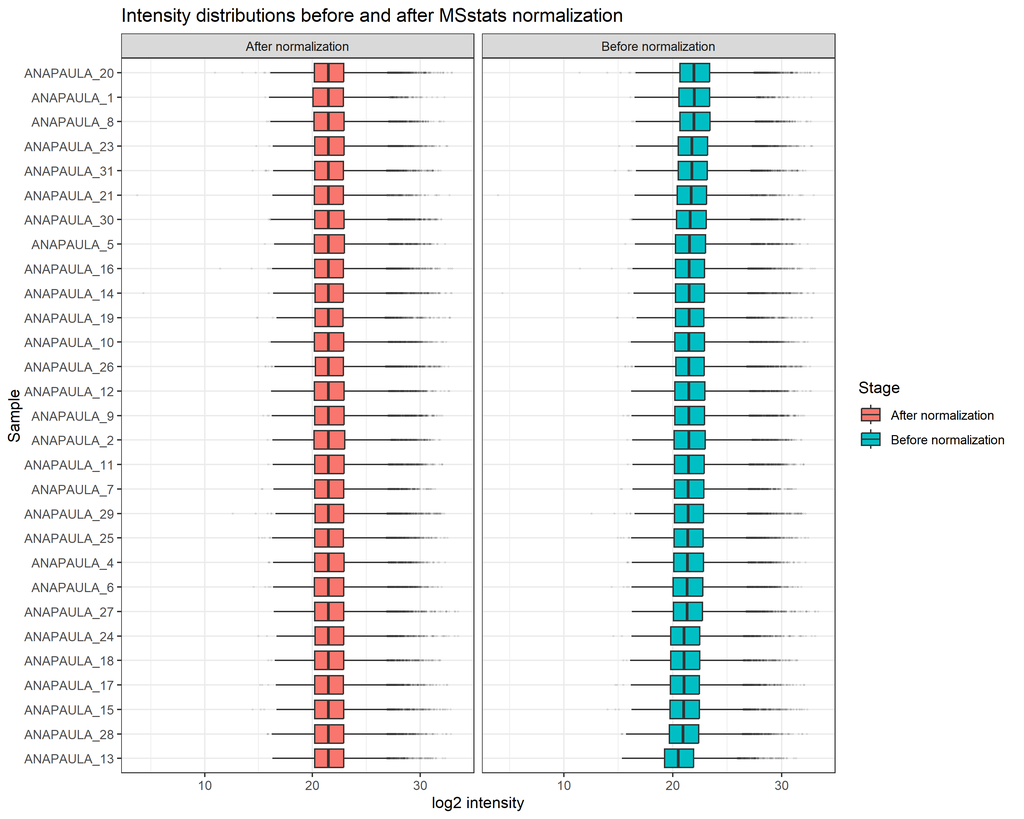

Sample intensity distributions before and after MSstats normalization.

```r
normalization_distribution <- bind_rows(
  extract_distribution_data(msstats_input, "Before normalization"),
  extract_normalized_distribution_data(msstats_input, params$normalization)
)

if (nrow(normalization_distribution) > 0) {
  normalization_distribution |>
    left_join(
      annotation |> select(.data$Run, .data$FigureLabel),
      by = "Run"
    ) |>
    mutate(FigureLabel = coalesce(.data$FigureLabel, .data$Run)) |>
    ggplot(aes(x = reorder(.data$FigureLabel, .data$log2Intensity, median),
               y = .data$log2Intensity, fill = .data$Stage)) +
    geom_boxplot(outlier.alpha = 0.08, outlier.size = 0.3) +
    coord_flip() +
    facet_wrap(~ Stage, scales = "free_x") +
    labs(x = "Sample", y = "log2 intensity",
         title = "Intensity distributions before and after MSstats normalization") +
    theme_bw()
} else {
  message("Normalization diagnostic skipped: intensity columns were not found.")
}
```

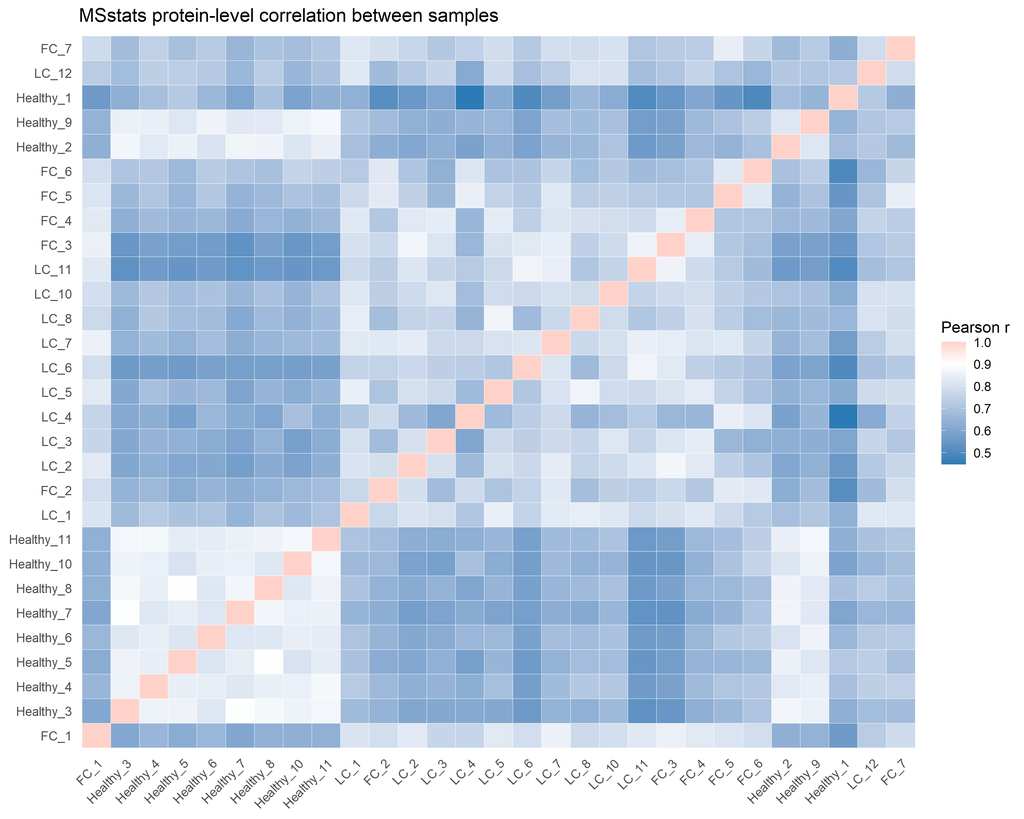

Pearson correlations among MSstats protein-level abundance profiles; samples are labeled by condition and biological replicate.

```r
protein_level_matrix <- make_protein_level_matrix(processed)

plot_correlation_heatmap(
  protein_level_matrix,
  processed_sample_annotation,
  title = "MSstats protein-level correlation between samples"
)
```

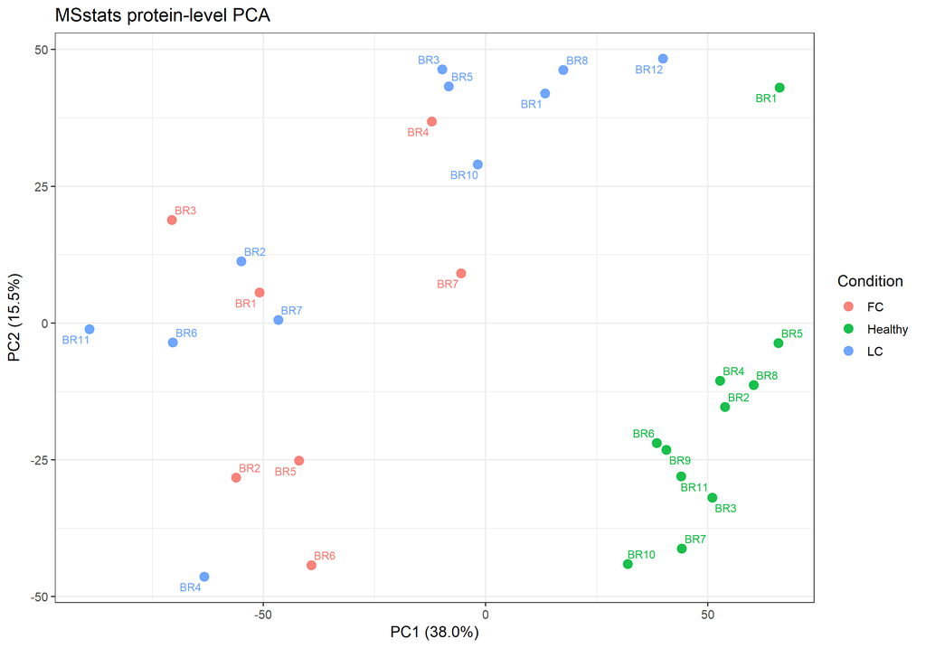

Principal component analysis of MSstats protein-level abundance profiles, colored by condition and labeled by biological replicate (BR#).

```r
plot_pca_from_matrix(
  protein_level_matrix,
  processed_sample_annotation,
  title = "MSstats protein-level PCA"
)
```

```r
protein_col <- first_existing_col(protein_level_tbl, c("Protein", "PROTEIN", "ProteinName"))
condition_col <- first_existing_col(protein_level_tbl, c("GROUP_ORIGINAL", "GROUP", "Condition", "Condition_ORIGINAL"))
value_col <- first_existing_col(protein_level_tbl, c("LogIntensities", "log2Intensity", "ABUNDANCE", "Intensity"))

if (!is.null(protein_col) && !is.null(condition_col) && !is.null(value_col)) {
  protein_cv <- protein_level_tbl |>
    transmute(
      Protein = as.character(.data[[protein_col]]),
      Condition = as.character(.data[[condition_col]]),
      linearIntensity = 2^coerce_log2_intensity(.data[[value_col]], value_col)
    ) |>
    filter(is.finite(.data$linearIntensity), .data$linearIntensity > 0) |>
    group_by(.data$Protein, .data$Condition) |>
    summarise(
      n_samples = n(),
      mean_intensity = mean(.data$linearIntensity, na.rm = TRUE),
      sd_intensity = stats::sd(.data$linearIntensity, na.rm = TRUE),
      .groups = "drop"
    ) |>
    mutate(cv_percent = 100 * .data$sd_intensity / .data$mean_intensity) |>
    filter(.data$n_samples >= 2, is.finite(.data$cv_percent))

  protein_cv |>
    group_by(.data$Condition) |>
    summarise(
      proteins = n(),
      median_cv_percent = median(.data$cv_percent, na.rm = TRUE),
      p75_cv_percent = stats::quantile(.data$cv_percent, 0.75, na.rm = TRUE),
      p90_cv_percent = stats::quantile(.data$cv_percent, 0.90, na.rm = TRUE),
      .groups = "drop"
    ) |>
    knitr::kable(
      digits = 2,
      caption = "Within-condition protein abundance coefficient-of-variation summary."
    )
} else {
  protein_cv <- tibble()
  message("Protein-level CV skipped: required protein, condition, or intensity columns were not found.")
}
```

Within-condition protein abundance coefficient-of-variation summary.

| Condition | proteins | median_cv_percent | p75_cv_percent | p90_cv_percent |
| --- | --- | --- | --- | --- |
| FC | 6277 | 49.67 | 66.38 | 85.15 |
| Healthy | 5028 | 46.17 | 59.58 | 77.04 |
| LC | 6366 | 63.82 | 83.40 | 106.76 |

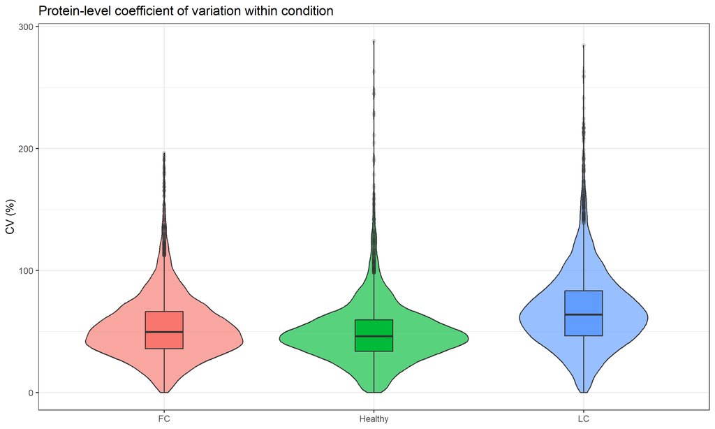

Distributions of within-condition protein-level coefficients of variation.

```r
if (nrow(protein_cv) > 0) {
  ggplot(protein_cv, aes(x = .data$Condition, y = .data$cv_percent,
                         fill = .data$Condition)) +
    geom_violin(trim = TRUE, alpha = 0.65, show.legend = FALSE) +
    geom_boxplot(width = 0.18, outlier.alpha = 0.15, show.legend = FALSE) +
    labs(x = NULL, y = "CV (%)",
         title = "Protein-level coefficient of variation within condition") +
    theme_bw()
}
```

```r
if (nrow(protein_cv) > 0) {
  protein_cv |>
    arrange(desc(.data$cv_percent)) |>
    mutate(
      `Gene names` = map_uniprot_to_gene_symbol(.data$Protein),
      .after = Protein
    ) |>
    select(Protein, `Gene names`, Condition, n_samples, cv_percent) |>
    slice_head(n = params$qc_top_cv_proteins) |>
    knitr::kable(
      digits = 2,
      caption = "Proteins with the highest within-condition coefficients of variation."
    )
}
```

Proteins with the highest within-condition coefficients of variation.

| Protein | Gene names | Condition | n_samples | cv_percent |
| --- | --- | --- | --- | --- |
| P23528; Q9Y281 | CFL1/CFL2 | Healthy | 11 | 288.06 |
| P08779 | KRT16 | LC | 11 | 284.55 |
| A0A0C2IVY9; O60814; Q8N257 | H2BC12/H2BC26 | LC | 10 | 262.92 |
| P11277 | SPTB | Healthy | 9 | 262.81 |
| P04259; P48668 | KRT6B/KRT6C | LC | 10 | 259.48 |
| P02538; P04259; P13647; P48668 | KRT6A/KRT6B/KRT5/KRT6C | LC | 10 | 258.60 |
| A0A0C2J363 | NA | Healthy | 8 | 247.80 |
| P02042 | HBD | Healthy | 11 | 244.96 |
| P0DOX3 | NA | Healthy | 8 | 244.59 |
| P02533 | KRT14 | LC | 11 | 241.22 |
| P03973 | SLPI | LC | 11 | 232.92 |
| P16157 | ANK1 | Healthy | 7 | 229.19 |
| P02730 | SLC4A1 | Healthy | 10 | 227.32 |
| P58107; Q15149 | EPPK1/PLEC | LC | 10 | 224.38 |
| Q14CN4; Q3SY84; Q7RTS7; Q86Y46 | KRT72/KRT71/KRT74/KRT73 | LC | 8 | 220.88 |
| P54652 | HSPA2 | LC | 8 | 219.41 |
| P12035 | KRT3 | LC | 8 | 217.24 |
| P10412; P16402; P16403; Q02539 | H1-4/H1-3/H1-2/H1-1 | LC | 10 | 216.81 |
| P13647 | KRT5 | LC | 11 | 216.60 |
| P14923; P35222 | JUP/CTNNB1 | LC | 10 | 216.56 |
| P01782 | NA | LC | 10 | 214.09 |
| O75828; P16152 | CBR3/CBR1 | LC | 10 | 213.24 |
| Q8WVV4 | POF1B | LC | 8 | 213.13 |
| O43175 | PHGDH | LC | 11 | 213.03 |
| P13797 | PLS3 | LC | 11 | 211.66 |

## MSstats Analysis: Healthy, FC, and LC

This analysis preserves the three conditions in the annotation file and tests FC vs Healthy, LC vs Healthy, and LC vs FC.

```r
three_condition_contrasts <- tibble::tribble(
  ~label, ~numerator, ~denominator,
  "FC_vs_Healthy", "FC", "Healthy",
  "LC_vs_Healthy", "LC", "Healthy",
  "LC_vs_FC", "LC", "FC"
)

three_condition_contrast_matrix <- make_contrast_matrix(
  processed_groups(processed),
  three_condition_contrasts
)

infected_contrast_matrix <- make_weighted_contrast_matrix(
  groups = processed_groups(processed),
  label = "Infected_vs_Healthy",
  weights = c(FC = 0.5, LC = 0.5, Healthy = -1)
)

all_contrast_matrix <- rbind(
  three_condition_contrast_matrix,
  infected_contrast_matrix
)

all_comparison_results <- quietly_run(
  run_group_comparison_matrix(processed, all_contrast_matrix)
)
all_comparison_output <- all_comparison_results$results

saveRDS(
  list(
    msstats_input = msstats_input,
    processed_data = processed[["ProcessedData"]],
    protein_level_data = processed[["ProteinLevelData"]],
    annotation = annotation,
    comparison_results = all_comparison_output
  ),
  file.path(output_dir, "msstats_workbook_export_objects.rds")
)

three_condition_output <- all_comparison_output |>
  filter(.data$Label %in% three_condition_contrasts$label)
infected_output <- all_comparison_output |>
  filter(.data$Label == "Infected_vs_Healthy")

three_condition_file <- write_results(three_condition_output, "msstats_three_condition_group_comparison.csv")
infected_file <- write_results(infected_output, "msstats_infected_vs_healthy_group_comparison.csv")

knitr::kable(
  three_condition_contrast_matrix,
  caption = "Contrast matrix for FC, LC, and Healthy comparisons."
)
```

Contrast matrix for FC, LC, and Healthy comparisons.

|  | FC | Healthy | LC |
| --- | --- | --- | --- |
| FC_vs_Healthy | 1 | -1 | 0 |
| LC_vs_Healthy | 0 | -1 | 1 |
| LC_vs_FC | -1 | 0 | 1 |

Volcano plots are publication-quality static `EnhancedVolcano` figures. Labels use gene symbols, connectors reduce label ambiguity, and the complete significance legend is written below each plot. Automatic `ggbreak` split axes keep extreme tails from compressing the main protein cloud. Each figure is also exported as a vector PDF in the `figures` directory.

**FC vs Healthy**

```r
plot_volcano(three_condition_output, "FC_vs_Healthy")
```

[figure not shown]

Figure 1: Protein-level volcano plot for FC versus Healthy. Dashed thresholds show the configured adjusted-p-value and absolute log2-fold-change cutoffs.

#### Differentially expressed proteins

```r
prepare_de_table(three_condition_output, "FC_vs_Healthy") |>
  create_dt(paste0(params$request, "-FC-over-Healthy-DE-proteins"))
```

| Accession | Gene | log2FC | pvalue | adj.pvalue | Note |
| --- | --- | --- | --- | --- | --- |
| P32455 | GBP1 | 6.983439190101663 | 4.26e-09 | 6.76e-06 | Missing measurements: 0.8%; Imputed measurements: 0.5%; Power caution: 50% power for target \|log2FC\| = 1 (below 80%); estimated minimum \|log2FC\| = 1.43 |
| Q9BQE5 | APOL2 | 4.942714182639095 | 3.45e-09 | 6.76e-06 | Missing measurements: 0.7%; Imputed measurements: 0.5%; Power caution: 74% power for target \|log2FC\| = 1 (below 80%); estimated minimum \|log2FC\| = 1.08 |
| P31146 | CORO1A | 4.516930034389151 | 2.07e-09 | 6.76e-06 | Missing measurements: 0.7%; Imputed measurements: 0.5%; Power caution: 75% power for target \|log2FC\| = 1 (below 80%); estimated minimum \|log2FC\| = 1.07 |
| P08575 | PTPRC | 5.379531519717941 | 5.95e-09 | 7.08e-06 | Missing measurements: 0.7%; Imputed measurements: 0.6%; Power caution: 53% power for target \|log2FC\| = 1 (below 80%); estimated minimum \|log2FC\| = 1.38 |
| P04179 | SOD2 | 5.962704763087024 | 1.10e-08 | 8.21e-06 | Missing measurements: 0.7%; Imputed measurements: 0.7%; Power caution: 42% power for target \|log2FC\| = 1 (below 80%); estimated minimum \|log2FC\| = 1.6 |
| Q14019 | COTL1 | 5.596825318235536 | 1.14e-08 | 8.21e-06 | Missing measurements: 0.7%; Imputed measurements: 0.5%; Power caution: 50% power for target \|log2FC\| = 1 (below 80%); estimated minimum \|log2FC\| = 1.43 |
| P05107 | ITGB2 | 5.40911519604908 | 1.73e-08 | 8.21e-06 | Missing measurements: 0.7%; Imputed measurements: 0.6%; Power caution: 50% power for target \|log2FC\| = 1 (below 80%); estimated minimum \|log2FC\| = 1.42 |
| Q03519 | TAP2 | 4.770283955630354 | 1.46e-08 | 8.21e-06 | Missing measurements: 0.7%; Imputed measurements: 0.6%; Power caution: 62% power for target \|log2FC\| = 1 (below 80%); estimated minimum \|log2FC\| = 1.24 |
| P62312 | LSM6 | 2.871742611347168 | 1.27e-08 | 8.21e-06 | Missing measurements: 0.2%; Imputed measurements: 0.2% |
| O60264 | SMARCA5 | 2.816865173054895 | 1.61e-08 | 8.21e-06 | Missing measurements: 0.7%; Imputed measurements: 0.7% |

[output cut: 1832 more lines]

**LC vs Healthy**

```r
plot_volcano(three_condition_output, "LC_vs_Healthy")
```

[figure not shown]

Figure 2: Protein-level volcano plot for LC versus Healthy. Dashed thresholds show the configured adjusted-p-value and absolute log2-fold-change cutoffs.

#### Differentially expressed proteins

```r
prepare_de_table(three_condition_output, "LC_vs_Healthy") |>
  create_dt(paste0(params$request, "-LC-over-Healthy-DE-proteins"))
```

| Accession | Gene | log2FC | pvalue | adj.pvalue | Note |
| --- | --- | --- | --- | --- | --- |
| P04179 | SOD2 | 6.55156415044411 | 5.23e-10 | 1.78e-06 | Missing measurements: 0.6%; Imputed measurements: 0.6%; Power caution: 51% power for target \|log2FC\| = 1 (below 80%); estimated minimum \|log2FC\| = 1.41 |
| P05107 | ITGB2 | 6.108696082950249 | 7.47e-10 | 1.78e-06 | Missing measurements: 0.6%; Imputed measurements: 0.6%; Power caution: 60% power for target \|log2FC\| = 1 (below 80%); estimated minimum \|log2FC\| = 1.26 |
| P59665; P59666 | DEFA1/DEFA3 | 9.431675434870051 | 1.80e-09 | 1.93e-06 | Missing measurements: 0.5%; Imputed measurements: 0.5%; Power caution: 25% power for target \|log2FC\| = 1 (below 80%); estimated minimum \|log2FC\| = 2.21 |
| P32455 | GBP1 | 6.673159248716959 | 2.03e-09 | 1.93e-06 | Missing measurements: 0.7%; Imputed measurements: 0.4%; Power caution: 59% power for target \|log2FC\| = 1 (below 80%); estimated minimum \|log2FC\| = 1.28 |
| P31146 | CORO1A | 3.990086063414028 | 2.03e-09 | 1.93e-06 | Missing measurements: 0.7%; Imputed measurements: 0.4% |
| P08575 | PTPRC | 4.991569329435889 | 2.97e-09 | 2.02e-06 | Missing measurements: 0.7%; Imputed measurements: 0.6%; Power caution: 64% power for target \|log2FC\| = 1 (below 80%); estimated minimum \|log2FC\| = 1.21 |
| P25774 | CTSS | 4.478494912142928 | 2.91e-09 | 2.02e-06 | Missing measurements: 0.7%; Imputed measurements: 0.5%; Power caution: 78% power for target \|log2FC\| = 1 (below 80%); estimated minimum \|log2FC\| = 1.03 |
| P62312 | LSM6 | 2.756935852310118 | 3.94e-09 | 2.34e-06 | Missing measurements: 0.2%; Imputed measurements: 0.2% |
| Q14019 | COTL1 | 5.318102234477498 | 4.69e-09 | 2.48e-06 | Missing measurements: 0.7%; Imputed measurements: 0.4%; Power caution: 60% power for target \|log2FC\| = 1 (below 80%); estimated minimum \|log2FC\| = 1.27 |
| Q7Z7G0 | ABI3BP | -5.798500922509739 | 6.81e-09 | 3.24e-06 | Missing measurements: 0.6%; Imputed measurements: 0.5%; Power caution: 56% power for target \|log2FC\| = 1 (below 80%); estimated minimum \|log2FC\| = 1.33 |

[output cut: 1662 more lines]

**LC vs FC**

```r
plot_volcano(three_condition_output, "LC_vs_FC")
```

[figure not shown]

Figure 3: Protein-level volcano plot for LC versus FC. Dashed thresholds show the configured adjusted-p-value and absolute log2-fold-change cutoffs.

#### Differentially expressed proteins

```r
prepare_de_table(three_condition_output, "LC_vs_FC") |>
  create_dt(paste0(params$request, "-LC-over-FC-DE-proteins"))
```

| Accession | Gene | log2FC | pvalue | adj.pvalue | Note |
| --- | --- | --- | --- | --- | --- |

## MSstats Analysis: Infected vs Healthy

This analysis tests the average infected effect from the three-condition model: `(FC + LC) / 2 - Healthy`. It reuses the processed MSstats model above instead of collapsing FC and LC before conversion.

```r
annotation |>
  mutate(InfectionStatus = if_else(Condition == "Healthy", "Healthy", "Infected")) |>
  count(InfectionStatus, Condition, name = "runs") |>
  arrange(InfectionStatus, Condition) |>
  knitr::kable(
    caption = "Runs contributing to the Infected-versus-Healthy comparison."
  )
```

Runs contributing to the Infected-versus-Healthy comparison.

| InfectionStatus | Condition | runs |
| --- | --- | --- |
| Healthy | Healthy | 11 |
| Infected | FC | 7 |
| Infected | LC | 11 |

```r
knitr::kable(
  infected_contrast_matrix,
  caption = "Contrast matrix for the Infected-versus-Healthy comparison."
)
```

Contrast matrix for the Infected-versus-Healthy comparison.

|  | FC | Healthy | LC |
| --- | --- | --- | --- |
| Infected_vs_Healthy | 0.5 | -1 | 0.5 |

The infected contrast uses the same publication-quality static volcano styling as the three-condition comparisons.

```r
plot_volcano(infected_output, "Infected_vs_Healthy")
```

[figure not shown]

Figure 4: Protein-level volcano plot for the average infected effect, defined as (FC + LC)/2 minus Healthy.

### Differentially expressed proteins

```r
prepare_de_table(infected_output, "Infected_vs_Healthy") |>
  create_dt(paste0(params$request, "-Infected-over-Healthy-DE-proteins"))
```

| Accession | Gene | log2FC | pvalue | adj.pvalue | Note |
| --- | --- | --- | --- | --- | --- |
| P04179 | SOD2 | 6.257134456765567 | 2.53e-10 | 5.64e-07 | Missing measurements: 0.5%; Imputed measurements: 0.5%; Power caution: 60% power for target \|log2FC\| = 1 (below 80%); estimated minimum \|log2FC\| = 1.27 |
| P05107 | ITGB2 | 5.758905639499664 | 4.75e-10 | 5.64e-07 | Missing measurements: 0.6%; Imputed measurements: 0.5%; Power caution: 68% power for target \|log2FC\| = 1 (below 80%); estimated minimum \|log2FC\| = 1.15 |
| P08575 | PTPRC | 5.185550424576915 | 4.47e-10 | 5.64e-07 | Missing measurements: 0.6%; Imputed measurements: 0.5%; Power caution: 72% power for target \|log2FC\| = 1 (below 80%); estimated minimum \|log2FC\| = 1.1 |
| P31146 | CORO1A | 4.25350804890159 | 2.10e-10 | 5.64e-07 | Missing measurements: 0.6%; Imputed measurements: 0.4% |
| P32455 | GBP1 | 6.828299219409312 | 6.25e-10 | 5.93e-07 | Missing measurements: 0.7%; Imputed measurements: 0.4%; Power caution: 66% power for target \|log2FC\| = 1 (below 80%); estimated minimum \|log2FC\| = 1.19 |
| P62312 | LSM6 | 2.814339231828643 | 7.66e-10 | 6.07e-07 | Missing measurements: 0.2%; Imputed measurements: 0.2% |
| Q14019 | COTL1 | 5.457463776356517 | 9.92e-10 | 6.57e-07 | Missing measurements: 0.7%; Imputed measurements: 0.4%; Power caution: 68% power for target \|log2FC\| = 1 (below 80%); estimated minimum \|log2FC\| = 1.15 |
| Q9BQE5 | APOL2 | 4.427612103092783 | 1.11e-09 | 6.57e-07 | Missing measurements: 0.6%; Imputed measurements: 0.4% |
| P25774 | CTSS | 4.339230793341485 | 1.30e-09 | 6.87e-07 | Missing measurements: 0.6%; Imputed measurements: 0.5% |
| Q03519 | TAP2 | 4.553248269579033 | 1.66e-09 | 7.90e-07 | Missing measurements: 0.6%; Imputed measurements: 0.5%; Power caution: 80% power for target \|log2FC\| = 1 (below 80%); estimated minimum \|log2FC\| = 1 |

[output cut: 1997 more lines]

## Gene Set Enrichment Analysis

```r
gsea_comparison_labels <- c(
  three_condition_contrasts$label,
  "Infected_vs_Healthy"
)

gsea_results <- purrr::set_names(gsea_comparison_labels) |>
  purrr::map(function(comparison_label) {
    run_go_bp_gsea(
      all_comparison_output,
      comparison_label = comparison_label,
      min_gene_set_size = params$gsea_min_gene_set_size,
      max_gene_set_size = params$gsea_max_gene_set_size,
      pvalue_cutoff = params$gsea_pvalue_cutoff,
      dot_show_categories = params$gsea_dot_show_categories,
      tree_show_categories = params$gsea_tree_show_categories,
      tree_label_wrap = params$gsea_tree_label_wrap
    )
  })

gsea_run_summary <- summarize_gsea_runs(gsea_results)
gsea_run_summary_file <- write_results(gsea_run_summary, "gsea_go_bp_run_summary.csv")

gsea_combined_table <- purrr::imap_dfr(gsea_results, function(result, comparison_label) {
  result$table |>
    mutate(Comparison = comparison_label, .before = 1)
})
gsea_combined_file <- write_results(gsea_combined_table, "gsea_go_bp_all_comparisons.csv")

gsea_result_files <- purrr::imap_chr(gsea_results, function(result, comparison_label) {
  write_results(
    result$table,
    paste0("gsea_go_bp_", tolower(comparison_label), ".csv")
  )
})

knitr::kable(
  gsea_run_summary,
  caption = "GO Biological Process GSEA status and result counts by comparison."
)
```

GO Biological Process GSEA status and result counts by comparison.

| Comparison | input_proteins | unique_accessions | mapped_accessions | ranked_entrez_ids | tested_terms | returned_terms | dotplot_status | treeplot_status | status |
| --- | --- | --- | --- | --- | --- | --- | --- | --- | --- |
| FC vs Healthy | 4357 | 4357 | 4200 | 4243 | 24547 | 349 | Generated | Generated | 349 enriched GO BP terms returned. |
| LC vs Healthy | 4352 | 4352 | 4196 | 4239 | 24547 | 340 | Generated | Generated | 340 enriched GO BP terms returned. |
| LC vs FC | 4904 | 4904 | 4740 | 4786 | 24547 | 233 | Generated | Generated | 233 enriched GO BP terms returned. |
| Infected vs Healthy | 4350 | 4350 | 4194 | 4237 | 24547 | 356 | Generated | Generated | 356 enriched GO BP terms returned. |

### GSEA Dot Plots

```r
for (comparison_label in names(gsea_results)) {
  result <- gsea_results[[comparison_label]]
  cat("#### ", format_comparison_label(comparison_label), "\n\n", sep = "")
  if (!is.null(result$dotplot)) {
    print(result$dotplot)
  } else {
    cat("*", result$status, "*\n\n", sep = "")
  }
  cat("\n\n")
}
```

#### FC vs Healthy

#### LC vs Healthy

#### LC vs FC

#### Infected vs Healthy

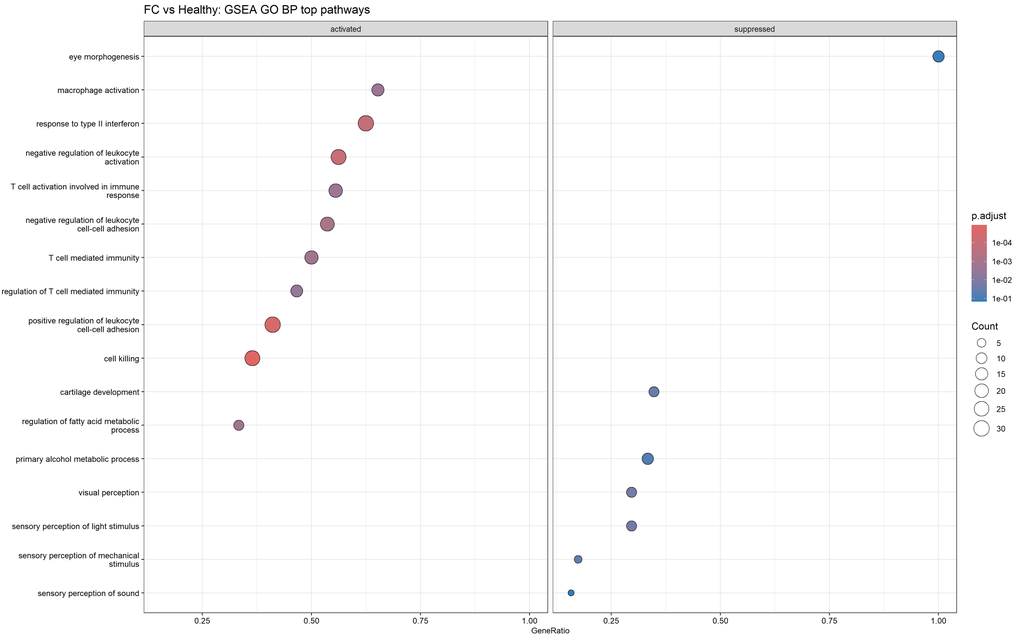

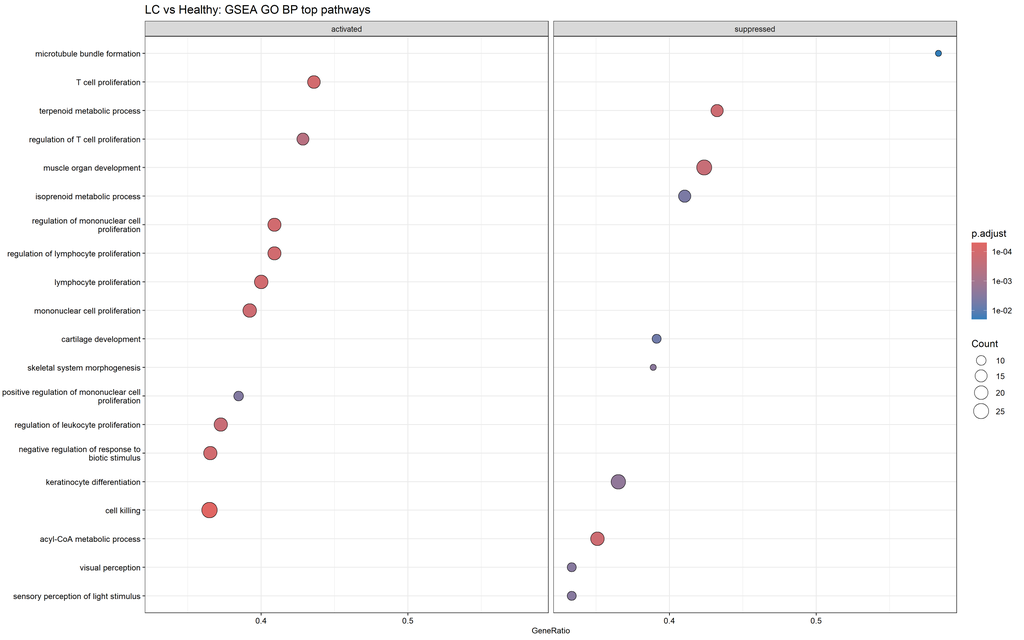

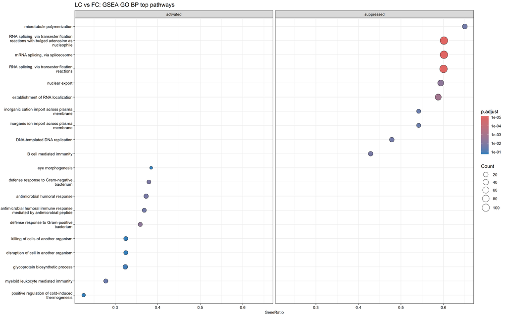

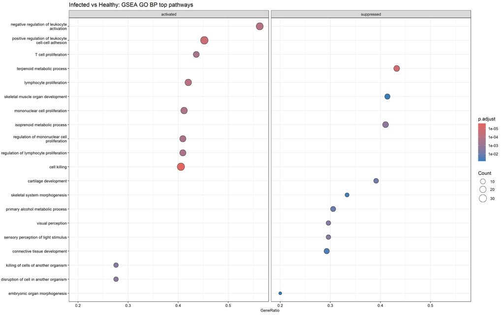

### GSEA Tree Plots

Tree plots group enriched GO terms by pairwise term similarity, making redundant or closely related biological processes easier to recognize.

```r
for (comparison_label in names(gsea_results)) {
  result <- gsea_results[[comparison_label]]
  cat("#### ", format_comparison_label(comparison_label), "\n\n", sep = "")
  if (!is.null(result$treeplot)) {
    print(result$treeplot)
  } else {
    cat("*Tree plot unavailable. ", result$status, "*\n\n", sep = "")
  }
  cat("\n\n")
}
```

#### FC vs Healthy

#### LC vs Healthy

#### LC vs FC

#### Infected vs Healthy

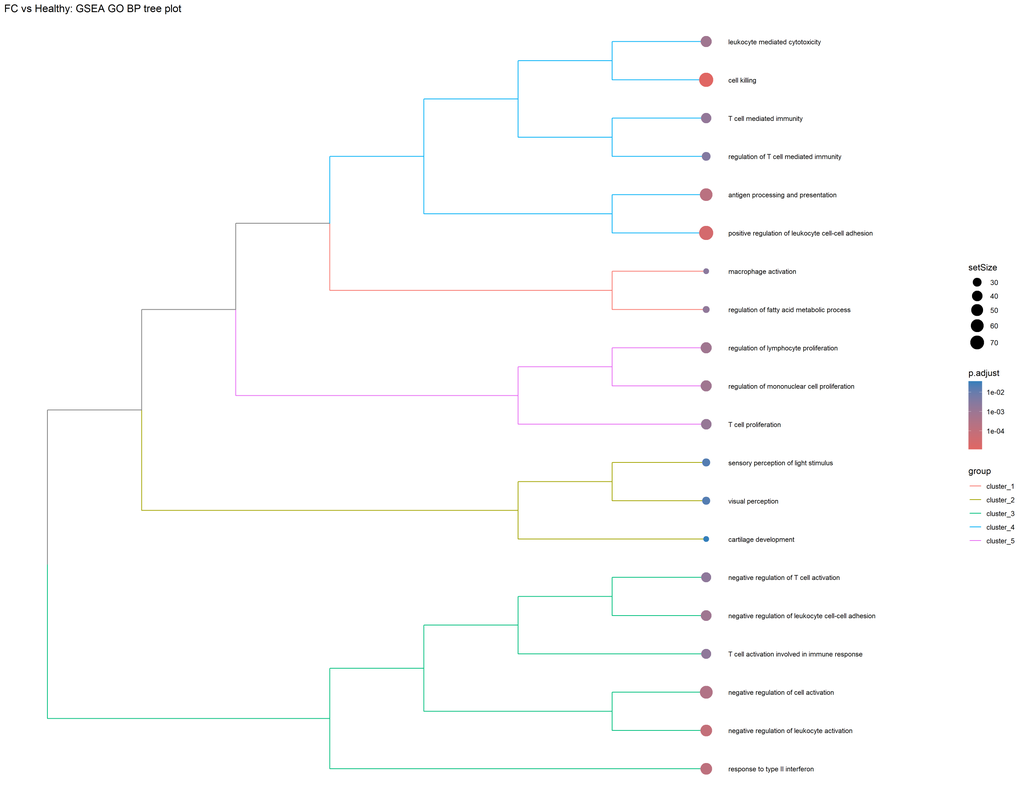

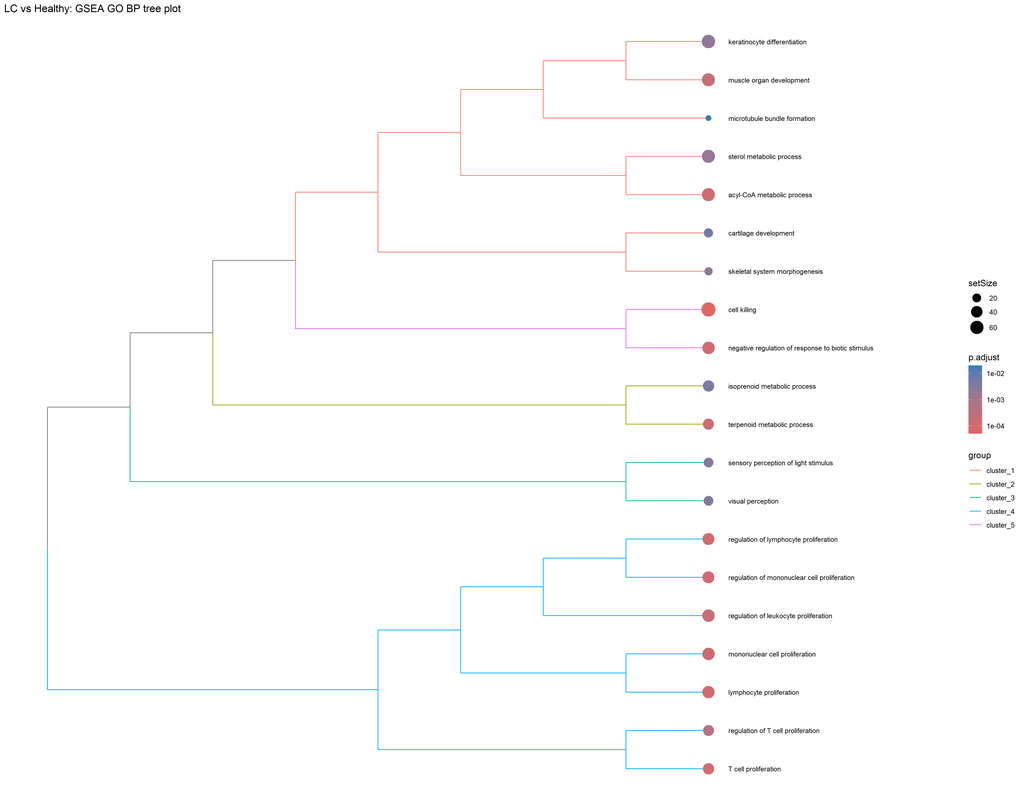

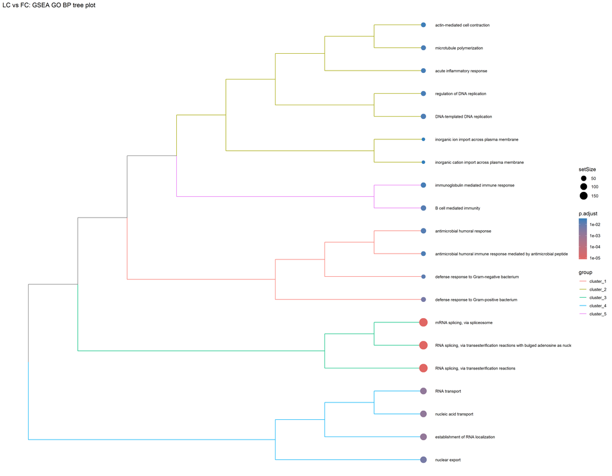

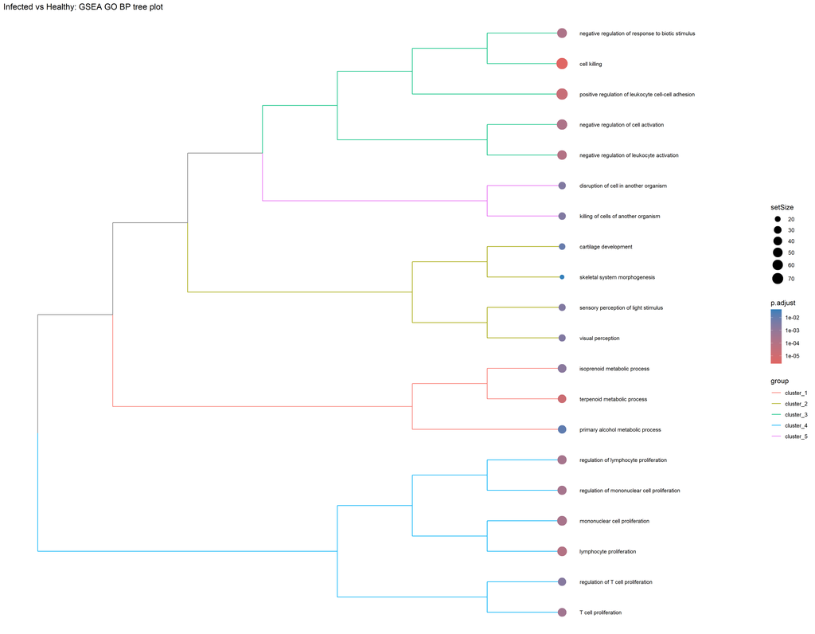

### GSEA Results Tables

`NES` is the normalized enrichment score, `p.adjust` is the Benjamini-Hochberg-adjusted p-value, and `core_enrichment` lists the leading-edge genes driving the enrichment score.

```r
invisible(DT::datatable(NULL))
for (comparison_label in names(gsea_results)) {
  result <- gsea_results[[comparison_label]]
  cat("#### ", format_comparison_label(comparison_label), "\n\n", sep = "")
  if (nrow(result$table) > 0) {
    table_widget <- DT::datatable(
      result$table,
      rownames = FALSE,
      caption = htmltools::tags$caption(
        style = "caption-side: top; text-align: left; font-weight: bold;",
        paste(
          "GO Biological Process GSEA results:",
          format_comparison_label(comparison_label)
        )
      ),
      extensions = "Buttons",
      options = list(
        dom = "lBfrtip",
        buttons = list(
          "copy",
          "csv",
          list(
            extend = "excel",
            filename = paste0(
              params$request, "-GSEA-",
              stringr::str_replace_all(tolower(comparison_label), "_", "-")
            ),
            title = paste(
              "GO Biological Process GSEA results:",
              format_comparison_label(comparison_label)
            )
          )
        ),
        pageLength = 10,
        lengthMenu = list(c(10, 25, 50, -1), c("10", "25", "50", "All")),
        scrollX = TRUE
      )
    ) |>
      DT::formatSignif(
        intersect(c("enrichmentScore", "NES", "pvalue", "p.adjust", "qvalue"), names(result$table)),
        digits = 3
      )
    print(htmltools::tagList(table_widget))
  } else {
    cat("*", result$status, "*\n\n", sep = "")
  }
  cat("\n\n")
}
```

#### FC vs Healthy

| ID | Description | setSize | enrichmentScore | NES | pvalue | p.adjust | qvalue | rank | leading_edge | core_enrichment | log2err |
| --- | --- | --- | --- | --- | --- | --- | --- | --- | --- | --- | --- |
| GO:0019217 | regulation of fatty acid metabolic process | 24 | 0.6869705498682426 | 1.813516975509082 | 8.340738906612224e-05 | 0.001738965375812548 | 0.001738965375812549 | 312 | tags=33%, list=7%, signal=31% | NME1/CD74/PLAA/EIF6/CPT1A/FABP5/UBR4/NME2 | 0.5384340963099162 |
| GO:0007601 | visual perception | 27 | -0.3895898598640188 | -1.807946331355773 | 0.00173892755420675 | 0.01746831770362235 | 0.01746831770362235 | 332 | tags=30%, list=8%, signal=27% | TGFBI/RDH11/EFEMP1/KRT12/TACSTD2/LUM/COL1A1/COL2A1 | 0.4550598673872295 |
| GO:0050953 | sensory perception of light stimulus | 27 | -0.3895898598640188 | -1.807946331355773 | 0.00173892755420675 | 0.01746831770362235 | 0.01746831770362235 | 332 | tags=30%, list=8%, signal=27% | TGFBI/RDH11/EFEMP1/KRT12/TACSTD2/LUM/COL1A1/COL2A1 | 0.4550598673872295 |
| GO:0002695 | negative regulation of leukocyte activation | 48 | 0.6317962197864277 | 1.800874419936314 | 1.781246889419852e-06 | 9.053700530743908e-05 | 9.053700530743908e-05 | 941 | tags=56%, list=22%, signal=44% | PTPRC/LGALS9/PTPN6/HLA-DRB1/MNDA/PSMA4/CSK/HMGB1/PSMB8/HLA-E/HLA-G/GRN/PSMA2/PSMA3/LYN/SRC/PSMB2/PRKAR1A/FN1/PSMB1/FGR/PSMA7/STAT5A/PSMB9/PSMB4/PSMB10/PSMA1 | 0.6435518361507222 |
| GO:0034341 | response to type II interferon | 48 | 0.6251003374648472 | 1.78178845073581 | 3.068689409990212e-06 | 0.000130419299924584 | 0.000130419299924584 | 964 | tags=62%, list=23%, signal=49% | GBP1/GBP2/STAT1/LGALS9/PSMA4/TRIM21/PSMB8/CD74/IFITM3/RPL13A/PSMA2/CD47/CASP1/PSMA3/HCK/PSMB2/SYNCRIP/EPRS1/CDC37/PSMB1/PSMA7/BST2/PSMB9/PSMB4/RAF1/PSMB10/SEC61A1/SP100/PSMA1/CALM1 | 0.6272567397185284 |
| GO:0042116 | macrophage activation | 23 | 0.6778655775092807 | 1.753207526843725 | 0.0001352426699366672 | 0.002410373391613181 | 0.002410373391613181 | 1100 | tags=65%, list=26%, signal=49% | PTPRC/ITGB2/ITGAM/HMGB1/CD74/GRN/MYO18A/CLU/DYSF/STK39/KARS1/PLCG2/C1QA/THBS1/PLA2G4A | 0.5188480777437918 |
| GO:0002709 | regulation of T cell mediated immunity | 30 | 0.6397295350666173 | 1.735613265065758 | 0.0001901824932065071 | 0.00323310238451062 | 0.00323310238451062 | 758 | tags=47%, list=18%, signal=39% | PTPRC/HLA-A/HLA-C/HLA-DRB1/HMGB1/CYRIB/HLA-B/HLA-E/HLA-G/STX7/NCKAP1L/HLA-DRB3/YWHAG/HLA-DRA | 0.5188480777437918 |
| GO:1903039 | positive regulation of leukocyte cell-cell adhesion | 73 | 0.5961125302277794 | 1.733262626210852 | 3.612913990402754e-07 | 2.802829001117217e-05 | 2.802829001117217e-05 | 653 | tags=41%, list=15%, signal=35% | PTPRC/ITGB2/HLA-A/LGALS9/PTPN6/HLA-DPB1/HLA-DRB1/CSK/HMGB1/CYRIB/SMARCC2/HLA-E/HLA-G/AP3B1/CD47/SMARCD2/HSPH1/SART1/HLA-DRB5/TFRC/RELA/LYN/SRC/YES1/CD44/SMARCE1/NCKAP1L/LCK/HLA-DRB3/YWHAG | 0.674962860011025 |
| GO:0001906 | cell killing | 74 | 0.5942501477307285 | 1.732861550237479 | 9.310740135188349e-08 | 1.143151983264792e-05 | 1.143151983264792e-05 | 594 | tags=36%, list=14%, signal=32% | CORO1A/GBP1/PTPRC/GBP2/HLA-A/HLA-C/LGALS9/HLA-DRB1/DEFA1/DEFA3/DEFA1B/ITGAM/SERPINB9/CYRIB/HLA-B/HLA-E/HLA-G/ICAM1/H2BC12/CTSC/GRB2/KRT6A/CLU/STX7/RPS19/RAB27A/NCKAP1L | 0.7049757151672383 |
| GO:1903038 | negative regulation of leukocyte cell-cell adhesion | 41 | 0.617038609668155 | 1.727742596434913 | 2.803008682425926e-05 | 0.0008016296791409707 | 0.0008016296791409706 | 1028 | tags=54%, list=24%, signal=41% | LGALS9/HLA-DRB1/PSMA4/CSK/HMGB1/PSMB8/HLA-E/HLA-G/PSMA2/PSMA3/WNK1/PSMB2/PRKAR1A/PSMB1/PSMA7/STAT5A/PSMB9/PSMB4/PSMB10/PSMA1/MIA3/CEBPB | 0.5756102610711286 |

[output cut: 339 more lines]

#### LC vs Healthy

| ID | Description | setSize | enrichmentScore | NES | pvalue | p.adjust | qvalue | rank | leading_edge | core_enrichment | log2err |
| --- | --- | --- | --- | --- | --- | --- | --- | --- | --- | --- | --- |
| GO:0048705 | skeletal system morphogenesis | 18 | -0.6531549451059712 | -2.399688678350907 | 0.0001408061728586133 | 0.002592218559347914 | 0.001971557938477967 | 476 | tags=39%, list=11%, signal=35% | LAMA5/FBN2/MAPK14/COL3A1/COL28A1/CTNNB1/COL2A1 | 0.5188480777437918 |
| GO:0006721 | terpenoid metabolic process | 37 | -0.5579630288450514 | -2.394448896799716 | 2.53366970157294e-06 | 0.0001416052896005047 | 0.0001077004220325375 | 393 | tags=43%, list=9%, signal=40% | MVD/SDR9C7/PMVK/RDH11/SDR16C5/ACAT2/FDFT1/LIPE/MVK/FDPS/RETSAT/HMGCS2/ALDH3A2/AKR1C3/ADH1B/HMGCS1 | 0.6272567397185284 |
| GO:0007601 | visual perception | 27 | -0.5380347406787485 | -2.212256097466539 | 0.0001648647742231548 | 0.002892861585196919 | 0.002200217339948246 | 337 | tags=33%, list=8%, signal=31% | RDH11/TGFBI/ABLIM1/KRT12/EFEMP1/TACSTD2/COL1A1/COL2A1/LUM | 0.5188480777437918 |
| GO:0050953 | sensory perception of light stimulus | 27 | -0.5380347406787485 | -2.212256097466539 | 0.0001648647742231548 | 0.002892861585196919 | 0.002200217339948246 | 337 | tags=33%, list=8%, signal=31% | RDH11/TGFBI/ABLIM1/KRT12/EFEMP1/TACSTD2/COL1A1/COL2A1/LUM | 0.5188480777437918 |
| GO:0006637 | acyl-CoA metabolic process | 57 | -0.4494260801178602 | -2.141556715906875 | 2.717471452397731e-06 | 0.0001416052896005047 | 0.0001077004220325375 | 464 | tags=35%, list=11%, signal=32% | FITM2/SUCLG2/TECR/MVD/PMVK/ALDH7A1/BCKDHA/PDHB/MVK/ACSL5/HMGCS2/ACSL1/ACAT1/DBT/ACOT1/ACACA/ACACB/ACSS2/HMGCS1/FASN | 0.6272567397185284 |
| GO:0007517 | muscle organ development | 59 | -0.4385857007087026 | -2.094594114545069 | 4.44936285730761e-06 | 0.0001932779758152168 | 0.0001470010027423384 | 395 | tags=42%, list=9%, signal=39% | UNC45A/IGSF8/MYLK2/COL3A1/CAV2/ACTA1/CAV1/FHL1/FLNB/EFEMP2/GPC1/SGCD/MYLK/LAMA2/CTNNB1/UTRN/ASS1/DSP/DES/TPM1/COL6A1/PLEC/LMNA/COL6A3/MYH14 | 0.610526878385931 |
| GO:0051216 | cartilage development | 23 | -0.5456643092244156 | -2.079863349246249 | 0.0004758239307469896 | 0.006072162207146243 | 0.004618290984783549 | 380 | tags=39%, list=9%, signal=36% | MAPK14/COL3A1/NFIB/TGFBI/GPLD1/EFEMP1/COL2A1/LUM/OGN | 0.4984931087665903 |
| GO:0001578 | microtubule bundle formation | 12 | -0.663932147793264 | -2.039006112129079 | 0.002652896519662374 | 0.0198613519438723 | 0.01510590453595726 | 470 | tags=58%, list=11%, signal=52% | ODAD4/DNAH1/MAP1B/TPPP3/MTCL1/NUMA1/DNAAF1 | 0.4317076958033464 |
| GO:0030216 | keratinocyte differentiation | 63 | -0.3870704399613576 | -2.029204822936648 | 0.0001046007970887891 | 0.002060819212819476 | 0.001567392712373847 | 300 | tags=37%, list=7%, signal=34% | ALOX15B/KRT78/KRT79/PKP1/KLK5/KRT80/KRT4/KRT7/DSP/NUMA1/PLEC/KRT14/AKR1C3/KRT71/KRT74/KRT72/KRT73/SCEL/KRT5/PPL/EVPL/KRT75/KRT77 | 0.5384340963099162 |
| GO:0006720 | isoprenoid metabolic process | 39 | -0.4344366203261104 | -1.970765587151795 | 0.0002917032359816831 | 0.004310299131676712 | 0.003278274680823838 | 393 | tags=41%, list=9%, signal=38% | MVD/SDR9C7/PMVK/RDH11/SDR16C5/ACAT2/FDFT1/LIPE/MVK/FDPS/RETSAT/HMGCS2/ALDH3A2/AKR1C3/ADH1B/HMGCS1 | 0.4984931087665903 |

[output cut: 330 more lines]

#### LC vs FC

| ID | Description | setSize | enrichmentScore | NES | pvalue | p.adjust | qvalue | rank | leading_edge | core_enrichment | log2err |
| --- | --- | --- | --- | --- | --- | --- | --- | --- | --- | --- | --- |
| GO:0050830 | defense response to Gram-positive bacterium | 39 | 0.4943056645573194 | 2.199410131106513 | 4.580509620375227e-05 | 0.00473458130760603 | 0.00473458130760603 | 423 | tags=36%, list=9%, signal=33% | DEFA1/DEFA3/DEFA1B/PLA2G2A/PGLYRP1/RPL39/RNASE3/FGR/CAMP/TLR2/DEFB103A/DEFB103B/CASP4/H2BC12 | 0.557332238758646 |
| GO:0050829 | defense response to Gram-negative bacterium | 29 | 0.5164663669877457 | 2.059485459466691 | 0.000167620975604477 | 0.01270566995081936 | 0.01270566995081936 | 473 | tags=38%, list=10%, signal=34% | DEFA1/DEFA3/DEFA1B/BPI/RNASE3/CAMP/DEFB103A/DEFB103B/H2BC12/AZU1/ELANE | 0.5188480777437918 |
| GO:0061844 | antimicrobial humoral immune response mediated by antimicrobial peptide | 38 | 0.4533498042434209 | 1.955632102183178 | 0.0005458732150849528 | 0.01939555767348723 | 0.01939555767348723 | 473 | tags=37%, list=10%, signal=33% | DEFA1/DEFA3/DEFA1B/PGLYRP1/BPI/RPL39/RNASE3/CAMP/CXCL13/DEFB103A/DEFB103B/H2BC26/H2BC12/ELANE | 0.4772708153628621 |
| GO:0019730 | antimicrobial humoral response | 51 | 0.4075989911012916 | 1.780580143731986 | 0.0003266501107227595 | 0.01535683595065256 | 0.01535683595065256 | 580 | tags=37%, list=12%, signal=33% | DEFA1/DEFA3/DEFA1B/PGLYRP1/BPI/RPL39/RNASE3/CAMP/CXCL13/DEFB103A/DEFB103B/H2BC26/H2BC12/AZU1/ELANE/PRTN3/SLPI/CXCL12/SPRR2A | 0.4984931087665903 |
| GO:0098659 | inorganic cation import across plasma membrane | 24 | -0.6307905706298294 | -1.723581714339728 | 0.001909909997840558 | 0.03338823863281942 | 0.03338823863281942 | 812 | tags=54%, list=17%, signal=45% | SLC39A14/PPP3CC/MS4A1/ATP1A2/ATP4A/ATP1B1/SLC30A1/NEDD4L/CACNA2D1/PPP3CA/PPP3CB/ATP1A1/STK39 | 0.4550598673872295 |
| GO:0099587 | inorganic ion import across plasma membrane | 24 | -0.6307905706298294 | -1.723581714339728 | 0.001909909997840558 | 0.03338823863281942 | 0.03338823863281942 | 812 | tags=54%, list=17%, signal=45% | SLC39A14/PPP3CC/MS4A1/ATP1A2/ATP4A/ATP1B1/SLC30A1/NEDD4L/CACNA2D1/PPP3CA/PPP3CB/ATP1A1/STK39 | 0.4550598673872295 |
| GO:0006261 | DNA-templated DNA replication | 46 | -0.5613070703578007 | -1.721695591888263 | 0.0005288964595407757 | 0.01939555767348723 | 0.01939555767348723 | 1186 | tags=48%, list=25%, signal=36% | PURA/CUL2/RECQL/RFC2/PNKP/NUCKS1/RPA1/MCMBP/SAMHD1/CUL4A/NBN/RFC3/CUL4B/MCM5/PCNA/NOC3L/MCM3/RRM1/MCM4/MCM6/POLD1/MCM2 | 0.4772708153628621 |
| GO:0000375 | RNA splicing, via transesterification reactions | 195 | -0.5018403984654738 | -1.706689135890403 | 1.195920241667574e-08 | 7.635829980759546e-06 | 7.635829980759544e-06 | 1584 | tags=60%, list=33%, signal=42% | HNRNPR/SNRPA1/ZC3H14/PSME3IP1/PPIH/SMU1/RBM7/SNU13/XAB2/PLRG…… | 0.7477396631498854 |
| GO:0000377 | RNA splicing, via transesterification reactions with bulged adenosine as nucleophile | 193 | -0.5017956343480936 | -1.695754210096076 | 2.014730865635764e-08 | 7.635829980759546e-06 | 7.635829980759544e-06 | 1584 | tags=60%, list=33%, signal=42% | HNRNPR/SNRPA1/ZC3H14/PSME3IP1/PPIH/SMU1/RBM7/SNU13/XAB2/PLRG…… | 0.7337619883564803 |
| GO:0000398 | mRNA splicing, via spliceosome | 193 | -0.5017956343480936 | -1.695754210096076 | 2.014730865635764e-08 | 7.635829980759546e-06 | 7.635829980759544e-06 | 1584 | tags=60%, list=33%, signal=42% | HNRNPR/SNRPA1/ZC3H14/PSME3IP1/PPIH/SMU1/RBM7/SNU13/XAB2/PLRG…… | 0.7337619883564803 |

[output cut: 223 more lines]

#### Infected vs Healthy

| ID | Description | setSize | enrichmentScore | NES | pvalue | p.adjust | qvalue | rank | leading_edge | core_enrichment | log2err |
| --- | --- | --- | --- | --- | --- | --- | --- | --- | --- | --- | --- |
| GO:0006721 | terpenoid metabolic process | 37 | -0.5522615128738546 | -2.874640782845846 | 1.396612353451002e-07 | 1.537670201149553e-05 | 1.099485801793303e-05 | 364 | tags=43%, list=9%, signal=40% | SDR16C5/APOE/SDR9C7/RDH11/ACAT2/FDPS/MVD/FDFT1/AKR1C3/RETSAT/ALDH3A2/HMGCS2/LIPE/MVK/ADH1B/HMGCS1 | 0.6901324587967956 |
| GO:0007601 | visual perception | 27 | -0.4931406824571217 | -2.144002811677501 | 0.0001461267972548142 | 0.002594929093186298 | 0.001855461393792865 | 283 | tags=30%, list=7%, signal=28% | RDH11/TGFBI/EFEMP1/KRT12/TACSTD2/COL1A1/COL2A1/LUM | 0.5188480777437918 |
| GO:0050953 | sensory perception of light stimulus | 27 | -0.4931406824571217 | -2.144002811677501 | 0.0001461267972548142 | 0.002594929093186298 | 0.001855461393792865 | 283 | tags=30%, list=7%, signal=28% | RDH11/TGFBI/EFEMP1/KRT12/TACSTD2/COL1A1/COL2A1/LUM | 0.5188480777437918 |
| GO:0006720 | isoprenoid metabolic process | 39 | -0.428409359913047 | -1.98277439387897 | 6.973386472585938e-05 | 0.001635617553932455 | 0.001169521446385707 | 364 | tags=41%, list=9%, signal=38% | SDR16C5/APOE/SDR9C7/RDH11/ACAT2/FDPS/MVD/FDFT1/AKR1C3/RETSAT/ALDH3A2/HMGCS2/LIPE/MVK/ADH1B/HMGCS1 | 0.5384340963099162 |
| GO:0001906 | cell killing | 74 | 0.6199663135957385 | 1.839095058587693 | 6.826526015078636e-09 | 2.505335047533859e-06 | 1.791398644156153e-06 | 667 | tags=41%, list=16%, signal=35% | CORO1A/PTPRC/GBP1/DEFA1/DEFA3/DEFA1B/GBP2/HLA-A/HLA-C/LGALS9/ITGAM/HLA-DRB1/CYRIB/SERPINB9/ICAM1/H2BC12/HLA-B/HLA-E/HLA-G/CTSC/GRB2/KRT6A/RPS19/STX7/CLU/RAB27A/HLA-DRA/SERPINB4/RPL30/NCKAP1L | 0.7614608014455848 |
| GO:0048705 | skeletal system morphogenesis | 18 | -0.4618747587487998 | -1.823830704507778 | 0.006673963663630939 | 0.04287426519770703 | 0.03065653858152307 | 496 | tags=33%, list=12%, signal=30% | FBN2/MGP/COL3A1/COL28A1/CTNNB1/COL2A1 | 0.4070179189239539 |
| GO:1903039 | positive regulation of leukocyte cell-cell adhesion | 73 | 0.6039975948512124 | 1.790332136870044 | 2.424447747489367e-07 | 2.224430808321494e-05 | 1.590542685286266e-05 | 814 | tags=45%, list=19%, signal=37% | PTPRC/ITGB2/HLA-A/LGALS9/PTPN6/HLA-DPB1/HLA-DRB1/CSK/CYRIB/HMGB1/AP3B1/HLA-E/HLA-G/CD47/TFRC/SMARCC2/HLA-DRB5/RELA/HSPH1/LYN/SRC/YES1/SART1/CD44/HLA-DRB3/LCK/NCK1/HLA-DRA/SMARCD2/NCKAP1L/YWHAG/SMARCE1… | 0.674962860011025 |
| GO:0042098 | T cell proliferation | 39 | 0.6354813329414539 | 1.789459717256941 | 1.324968795867966e-05 | 0.0003838922748027975 | 0.0002744958608473139 | 863 | tags=44%, list=20%, signal=35% | PTPRC/HLA-A/LGALS9/HLA-DPB1/HLA-DRB1/MSN/HMGB1/RAC2/CTPS1/HLA-E/HLA-G/TFRC/PRKAR1A/NCK1/NCKAP1L/NCK2/CEBPB | 0.5933254763964051 |
| GO:0051216 | cartilage development | 23 | -0.458767347293964 | -1.784764587455543 | 0.0007546924775443815 | 0.008655379351837125 | 0.006188886732255971 | 394 | tags=39%, list=9%, signal=36% | MGP/GPLD1/COL3A1/NFIB/TGFBI/EFEMP1/COL2A1/LUM/OGN | 0.4772708153628621 |
| GO:0002695 | negative regulation of leukocyte activation | 48 | 0.6299629264913336 | 1.782428750186153 | 2.31135070000706e-06 | 0.0001033076340487386 | 7.386842560162171e-05 | 904 | tags=56%, list=21%, signal=45% | PTPRC/LGALS9/PTPN6/HLA-DRB1/CSK/MNDA/PSMA4/HMGB1/GRN/PSMB8/HLA-E/HLA-G/PSMA2/PSMA3/LYN/SRC/FN1/PRKAR1A/PSMB2/PSMA7/FGR/PSMB1/PSMB9/PSMB4/STAT5A/CEBPB/PSMA1 | 0.6272567397185284 |

[output cut: 346 more lines]

## Power and Detectability

Power diagnostics are calculated from the MSstats contrast estimates, standard errors, and degrees of freedom. The prospective-style calculation asks whether the current design and observed variability would have 80% power to detect a target effect of 1 log2 fold change at a nominal alpha of 0.05. The observed-effect post-hoc power calculation uses the measured log2 fold change, so it should be read as a detectability diagnostic alongside the p-values rather than as independent evidence.

```r
tibble(
  setting = c(
    "Nominal alpha for power calculations",
    "FDR threshold used for detected proteins",
    "Target power",
    "Target absolute log2 fold-change",
    "Target linear fold-change"
  ),
  value = c(
    params$power_alpha,
    params$power_alpha,
    params$power_target,
    abs(params$power_effect_log2fc),
    round(2^abs(params$power_effect_log2fc), 3)
  )
) |>
  knitr::kable(caption = "Power-analysis settings used for all comparisons.")
```

Power-analysis settings used for all comparisons.

| setting | value |
| --- | --- |
| Nominal alpha for power calculations | 0.05 |
| FDR threshold used for detected proteins | 0.05 |
| Target power | 0.80 |
| Target absolute log2 fold-change | 1.00 |
| Target linear fold-change | 2.00 |

```r
power_diagnostics <- add_power_metrics(
  all_comparison_output,
  alpha = params$power_alpha,
  target_power = params$power_target,
  effect_log2fc = params$power_effect_log2fc
)

power_diagnostics_file <- write_results(power_diagnostics, "msstats_power_diagnostics.csv")

power_summary <- summarize_power_metrics(power_diagnostics)
power_summary |>
  knitr::kable(
    digits = 2,
    caption = "Power and minimum-detectable-effect summary by comparison."
  )
```

Power and minimum-detectable-effect summary by comparison.

[output not shown]

```r
power_diagnostics |>
  count(.data$Label, .data$power_detection_status, name = "proteins") |>
  group_by(.data$Label) |>
  mutate(percent = 100 * .data$proteins / sum(.data$proteins)) |>
  ungroup() |>
  arrange(.data$Label, desc(.data$proteins)) |>
  knitr::kable(
    digits = 2,
    caption = "Protein counts by power and differential-detection status."
  )
```

Protein counts by power and differential-detection status.

| Label | power_detection_status | proteins | percent |
| --- | --- | --- | --- |
| FC_vs_Healthy | FDR detected and at least target effect | 3055 | 43.48 |
| FC_vs_Healthy | Not FDR detected, underpowered for target effect | 2766 | 39.37 |
| FC_vs_Healthy | Insufficient information | 1054 | 15.00 |
| FC_vs_Healthy | Not FDR detected, powered for target effect | 106 | 1.51 |
| FC_vs_Healthy | FDR detected below target effect | 45 | 0.64 |
| Infected_vs_Healthy | FDR detected and at least target effect | 3397 | 48.35 |
| Infected_vs_Healthy | Not FDR detected, underpowered for target effect | 2319 | 33.01 |
| Infected_vs_Healthy | Insufficient information | 885 | 12.60 |
| Infected_vs_Healthy | Not FDR detected, powered for target effect | 287 | 4.08 |
| Infected_vs_Healthy | FDR detected below target effect | 138 | 1.96 |
| LC_vs_FC | Not FDR detected, underpowered for target effect | 4894 | 69.66 |
| LC_vs_FC | Insufficient information | 1402 | 19.95 |
| LC_vs_FC | Not FDR detected, powered for target effect | 475 | 6.76 |
| LC_vs_FC | FDR detected and at least target effect | 255 | 3.63 |
| LC_vs_Healthy | FDR detected and at least target effect | 2984 | 42.47 |
| LC_vs_Healthy | Not FDR detected, underpowered for target effect | 2806 | 39.94 |
| LC_vs_Healthy | Insufficient information | 959 | 13.65 |
| LC_vs_Healthy | Not FDR detected, powered for target effect | 198 | 2.82 |
| LC_vs_Healthy | FDR detected below target effect | 79 | 1.12 |

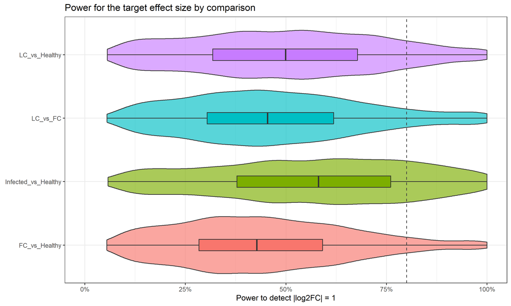

Figure 5: Estimated power to detect the configured target log2 fold change across proteins in each comparison.

```r
power_diagnostics |>
  filter(is.finite(.data$target_log2fc_power)) |>
  ggplot(aes(x = .data$Label, y = .data$target_log2fc_power, fill = .data$Label)) +
  geom_violin(trim = TRUE, alpha = 0.65, show.legend = FALSE) +
  geom_boxplot(width = 0.18, outlier.alpha = 0.15, show.legend = FALSE) +
  geom_hline(yintercept = params$power_target, linetype = "dashed", color = "grey25") +
  coord_flip() +
  scale_y_continuous(labels = scales::percent_format(accuracy = 1), limits = c(0, 1)) +
  labs(
    x = NULL,
    y = paste0("Power to detect |log2FC| = ", abs(params$power_effect_log2fc)),
    title = "Power for the target effect size by comparison"
  ) +
  theme_bw()
```

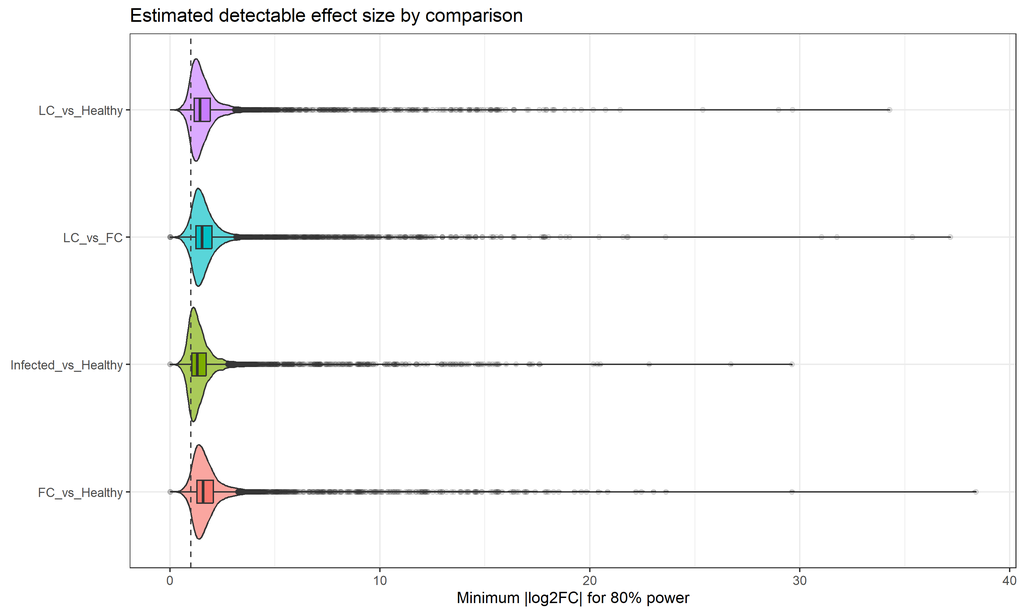

Figure 6: Estimated minimum absolute log2 fold change required to attain the target power for each comparison.

```r
power_diagnostics |>
  filter(is.finite(.data$detectable_log2fc_at_target_power)) |>
  ggplot(aes(x = .data$Label, y = .data$detectable_log2fc_at_target_power,
             fill = .data$Label)) +
  geom_violin(trim = TRUE, alpha = 0.65, show.legend = FALSE) +
  geom_boxplot(width = 0.18, outlier.alpha = 0.15, show.legend = FALSE) +
  geom_hline(yintercept = abs(params$power_effect_log2fc),
             linetype = "dashed", color = "grey25") +
  coord_flip() +
  labs(
    x = NULL,
    y = paste0("Minimum |log2FC| for ", scales::percent(params$power_target), " power"),
    title = "Estimated detectable effect size by comparison"
  ) +
  theme_bw()
```

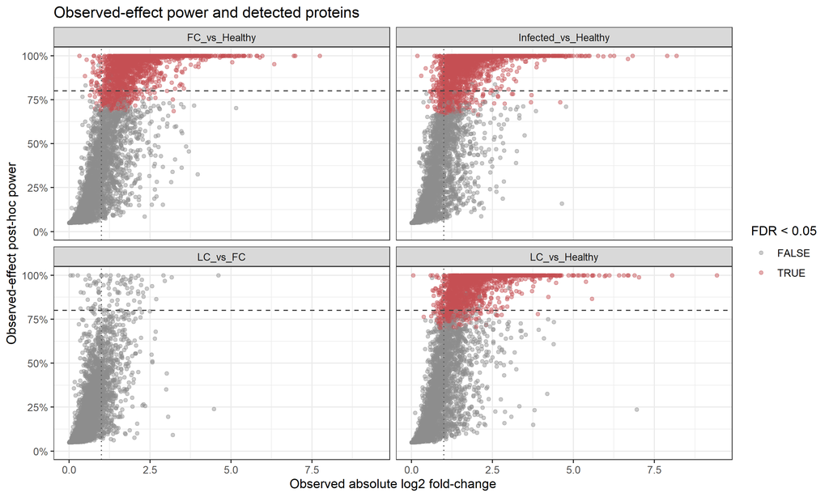

Figure 7: Observed-effect power versus absolute log2 fold change, stratified by comparison and FDR detection status.

```r
power_diagnostics |>
  filter(is.finite(.data$observed_effect_power), is.finite(.data$log2FC)) |>
  ggplot(aes(x = abs(.data$log2FC), y = .data$observed_effect_power,
             color = .data$fdr_detected)) +
  geom_point(alpha = 0.45, size = 1.4) +
  geom_hline(yintercept = params$power_target, linetype = "dashed", color = "grey25") +
  geom_vline(xintercept = abs(params$power_effect_log2fc),
             linetype = "dotted", color = "grey35") +
  facet_wrap(~ Label) +
  scale_y_continuous(labels = scales::percent_format(accuracy = 1), limits = c(0, 1)) +
  scale_color_manual(values = c("FALSE" = "grey55", "TRUE" = "#C44E52")) +
  labs(
    x = "Observed absolute log2 fold-change",
    y = "Observed-effect post-hoc power",
    color = paste0("FDR < ", params$power_alpha),
    title = "Observed-effect power and detected proteins"
  ) +
  theme_bw()
```

## Model Issue Summary

MSstats can annotate rows with model-fitting or comparison issues. This summary counts those flags by comparison so they are visible before exported result files are used downstream.

```r
add_issue_status <- function(results, analysis_label) {
  results <- as_plain_tibble(results)
  if (!"issue" %in% names(results)) {
    results$issue <- NA_character_
  }

  results |>
    mutate(
      analysis = analysis_label,
      issue = as.character(.data$issue),
      issue = if_else(is.na(.data$issue) | !nzchar(.data$issue),
                      "No issue", .data$issue)
    )
}

comparison_issue_summary <- bind_rows(
  add_issue_status(three_condition_output, "Three-condition"),
  add_issue_status(infected_output, "Infected vs Healthy")
) |>
  count(.data$analysis, .data$Label, .data$issue, name = "proteins") |>
  arrange(.data$analysis, .data$Label, desc(.data$proteins))

knitr::kable(
  comparison_issue_summary,
  caption = "MSstats model and comparison issue counts."
)
```

MSstats model and comparison issue counts.

| analysis | Label | issue | proteins |
| --- | --- | --- | --- |
| Infected vs Healthy | Infected_vs_Healthy | No issue | 5636 |
| Infected vs Healthy | Infected_vs_Healthy | oneConditionMissing | 1390 |
| Three-condition | FC_vs_Healthy | No issue | 5687 |
| Three-condition | FC_vs_Healthy | oneConditionMissing | 1213 |
| Three-condition | FC_vs_Healthy | completeMissing | 126 |
| Three-condition | LC_vs_FC | No issue | 6662 |
| Three-condition | LC_vs_FC | oneConditionMissing | 255 |
| Three-condition | LC_vs_FC | completeMissing | 109 |
| Three-condition | LC_vs_Healthy | No issue | 5669 |
| Three-condition | LC_vs_Healthy | oneConditionMissing | 1312 |
| Three-condition | LC_vs_Healthy | completeMissing | 45 |

## Conclusion

```r
render_analysis_conclusion(
  all_comparison_output,
  gsea_combined_table,
  fdr_cutoff = params$volcano_p_cutoff,
  log2fc_cutoff = params$volcano_fc_cutoff,
  power_summary = power_summary,
  target_power = params$power_target,
  power_effect_log2fc = params$power_effect_log2fc
)
```

### Differential protein analysis

Differential proteins were summarized at FDR < 0.05 and a large-effect threshold of |log2FC| >= 1.

The largest large-effect differential signal occurred for **Infected vs Healthy** (3,397 proteins), whereas **LC vs FC** had the smallest (255).

### Power analysis

Power was evaluated for a target |log2FC| of 1 (2.00-fold) at a target power of 80%.

- **FC vs Healthy**: median power was 43%; 6.6% of proteins met the power target, indicating limited power coverage. The median minimum detectable |log2FC| was 1.59.
- **Infected vs Healthy**: median power was 58%; 19.8% of proteins met the power target, indicating limited power coverage. The median minimum detectable |log2FC| was 1.30.
- **LC vs FC**: median power was 45%; 8.8% of proteins met the power target, indicating limited power coverage. The median minimum detectable |log2FC| was 1.53.
- **LC vs Healthy**: median power was 50%; 11.4% of proteins met the power target, indicating limited power coverage. The median minimum detectable |log2FC| was 1.44.

Non-significant results in **FC vs Healthy**, **Infected vs Healthy**, **LC vs FC**, **LC vs Healthy** should be interpreted cautiously because fewer than half of proteins were adequately powered for the target effect.

These calculations describe sensitivity under the fitted model and observed standard errors. Post-hoc power is effect-dependent and does not turn a non-significant result into evidence of no biological difference.

### Pathway analysis

- **FC vs Healthy**: 173 GO terms met the adjusted-p-value threshold. Leading terms were RNA splicing, via transesterification reactions with bulged adenosine as nucleophile (NES 1.68); mRNA splicing, via spliceosome (NES 1.68); RNA splicing, via transesterification reactions (NES 1.66).
- **LC vs Healthy**: 189 GO terms met the adjusted-p-value threshold. Leading terms were cytoplasmic translation (NES 1.80); cell killing (NES 1.83); phagocytosis (NES 1.78).
- **LC vs FC**: 77 GO terms met the adjusted-p-value threshold. Leading terms were RNA splicing, via transesterification reactions (NES -1.71); RNA splicing, via transesterification reactions with bulged adenosine as nucleophile (NES -1.70); mRNA splicing, via spliceosome (NES -1.70).
- **Infected vs Healthy**: 180 GO terms met the adjusted-p-value threshold. Leading terms were cytoplasmic translation (NES 1.72); leukocyte cell-cell adhesion (NES 1.74); cell killing (NES 1.84).

GSEA uses the full ranked protein list, so pathway-level enrichment may be present even when individual proteins do not pass both differential-analysis thresholds. Closely related GO terms are biologically redundant and should be interpreted together with the similarity trees and protein-level volcano plots.